# Project2

Michael

October 7, 2018

## description of dataset

The follow info are from kaggle OSMI Mental Health in Tech Survey 2016 Data on prevalence and attitudes towards mental health among tech workers Last Updated: 2 years ago (Version 1) About this Dataset OSMI Mental Health in Tech Survey 2016 Currently over 1400 responses, the ongoing 2016 survey aims to measure attitudes towards mental health in the tech workplace, and examine the frequency of mental health disorders among tech workers.

How Will This Data Be Used? We are interested in gauging how mental health is viewed within the tech/IT workplace, and the prevalence of certain mental health disorders within the tech industry. The Open Sourcing Mental Illness team of volunteers will use this data to drive our work in raising awareness and improving conditions for those with mental health disorders in the IT workplace.

# load package

```r
require(dplyr)
```

```r
require(ggplot2)
require(tidyr)
```

# load data

```r
df1 <- read.csv("mental-heath-in-tech-2016_20161114.csv")
```

# Explore data

```r
head(df1)
```

[output not shown]

[output cut: 365 more lines]

[output not shown]

```r
dim(df1)
```

```
## [1] 1433   63
```

# choose variables

```r
col_index <- c (1, 46:48, 51, 56:59)
df1.subset <- df1[, col_index]
```

# rename columns

```r
names(df1.subset)
```

```
## [1] "Are.you.self.employed."
## [2] "Do.you.have.a.family.history.of.mental.illness."
## [3] "Have.you.had.a.mental.health.disorder.in.the.past."
## [4] "Do.you.currently.have.a.mental.health.disorder."
## [5] "Have.you.been.diagnosed.with.a.mental.health.condition.by.a.medical.professional."
## [6] "What.is.your.age."
## [7] "What.is.your.gender."
## [8] "What.country.do.you.live.in."
## [9] "What.US.state.or.territory.do.you.live.in."
```

```r
df1.target <- rename (df1.subset,
                      Is_Employed ="Are.you.self.employed.",
                      family_hx ="Do.you.have.a.family.history.of.mental.illness.",
                      PMH ="Have.you.had.a.mental.health.disorder.in.the.past."   ,
                      Current ="Do.you.currently.have.a.mental.health.disorder."    ,
                      PMH_Pro ="Have.you.been.diagnosed.with.a.mental.health.condition.by.a.medical.professional.",

                      age= "What.is.your.age." ,
                      gender ="What.is.your.gender.",
                      country= "What.country.do.you.live.in." ,
                      state ="What.US.state.or.territory.do.you.live.in."

                      )


names(df1.target)
```

```
## [1] "Is_Employed" "family_hx"   "PMH"         "Current"     "PMH_Pro"
## [6] "age"         "gender"      "country"     "state"
```

# summary dataset

```r
summary(df1.target)
```

```
##   Is_Employed            family_hx      PMH       Current    PMH_Pro
##  Min.   :0.0000   I don't know:275   Maybe:246   Maybe:327   No :717
##  1st Qu.:0.0000   No          :488   No   :451   No   :531   Yes:716
##  Median :0.0000   Yes         :670   Yes  :736   Yes  :575
##  Mean   :0.2003
##  3rd Qu.:0.0000
##  Max.   :1.0000
##
##       age             gender                        country
##  Min.   :  3.00   Male   :610   United States of America:840
##  1st Qu.: 28.00   male   :249   United Kingdom          :180
##  Median : 33.00   Female :153   Canada                  : 78
##  Mean   : 34.29   female : 95   Germany                 : 58
##  3rd Qu.: 39.00   M      : 86   Netherlands             : 48
##  Max.   :323.00   m      : 79   Australia               : 35
##                   (Other):161   (Other)                 :194
##         state
##            :593
##  California:130
##  Illinois  : 56
##  Michigan  : 48
##  New York  : 45
##  Texas     : 43
##  (Other)   :518
```

# clean up Gender variables

```r
levels(df1.target$gender)
```

```
##  [1] ""
##  [2] " Female"
##  [3] "AFAB"
##  [4] "Agender"
##  [5] "Androgynous"
##  [6] "Bigender"
##  [7] "Cis-woman"
##  [8] "Cis female "
##  [9] "cis male"
## [10] "Cis male"
## [11] "Cis Male"
## [12] "cis man"
## [13] "cisdude"
## [14] "Cisgender Female"
## [15] "Dude"
```

[output cut: 57 more lines]

```r
female_levels = levels(df1.target$gender)[grep('(fe).*|^f$|fm|woman|female', levels(df1.target$gender), ignore.case = T, perl = T)]
male_levels   = levels(df1.target$gender)[grep('^m$|\bmale| male|mail|male |^male| man|\bman|^man$|masculine|dude|^male$', levels(df1.target$gender), ignore.case = T, perl = T)]
```

```r
df1.target$gender_new = df1.target$gender
df1.target$gender_new[df1.target$gender_new %in% female_levels] = 'female'
df1.target$gender_new[df1.target$gender_new %in% male_levels] = 'male'
df1.target$gender_new[!(df1.target$gender_new %in% c('male', 'female'))]  = NA
```

```r
summary(df1.target$gender_new %in% female_levels)
```

```
##    Mode   FALSE    TRUE
## logical    1088     345
```

```r
summary(df1.target$gender_new %in% male_levels)
```

```
##    Mode   FALSE    TRUE
## logical     375    1058
```

```r
summary(df1.target$gender_new %in% c(male_levels, female_levels))
```

```
##    Mode   FALSE    TRUE
## logical      30    1403
```

```r
df1.target$gender_new = droplevels(df1.target$gender_new)
table(df1.target$gender_new)
```

```
##
## female   male
##    345   1058
```

# visulization

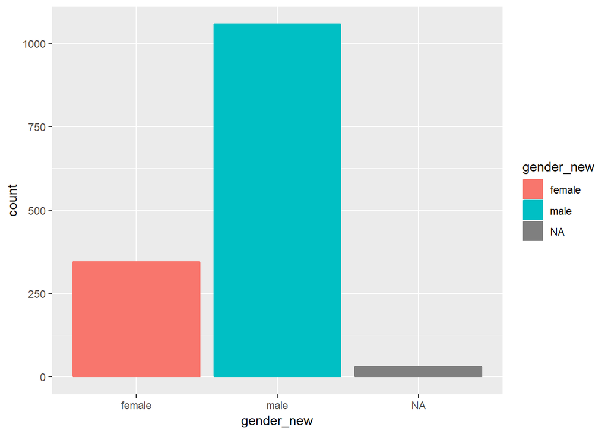

```r
pl <- ggplot(df1.target, aes(gender_new))+ geom_bar( aes(color= gender_new , fill=gender_new))
print (pl)
```

## Dataset2

# description dataset

Context Datascription of the dataset Columns - age: age of primary beneficiary

sex: insurance contractor gender, female, male

bmi: Body mass index, providing an understanding of body, weights that are relatively high or low relative to height, objective index of body weight (kg / m ^ 2) using the ratio of height to weight, ideally 18.5 to 24.9

children: Number of children covered by health insurance / Number of dependents

smoker: Smoking

```r
library(tidyverse)
df2 <- read.csv("insurance.csv")

head(df2)
```

```
##   age    sex    bmi children smoker    region   charges
## 1  19 female 27.900        0    yes southwest 16884.924
## 2  18   male 33.770        1     no southeast  1725.552
## 3  28   male 33.000        3     no southeast  4449.462
## 4  33   male 22.705        0     no northwest 21984.471
## 5  32   male 28.880        0     no northwest  3866.855
## 6  31 female 25.740        0     no southeast  3756.622
```

```r
str(df2)
```

```
## 'data.frame':    1338 obs. of  7 variables:
##  $ age     : int  19 18 28 33 32 31 46 37 37 60 ...
##  $ sex     : Factor w/ 2 levels "female","male": 1 2 2 2 2 1 1 1 2 1 ...
##  $ bmi     : num  27.9 33.8 33 22.7 28.9 ...
##  $ children: int  0 1 3 0 0 0 1 3 2 0 ...
##  $ smoker  : Factor w/ 2 levels "no","yes": 2 1 1 1 1 1 1 1 1 1 ...
##  $ region  : Factor w/ 4 levels "northeast","northwest",..: 4 3 3 2 2 3 3 2 1 2 ...
##  $ charges : num  16885 1726 4449 21984 3867 ...
```

```r
levels(df2$sex) <- c ("F", "M")
```

# creat Age group

```r
df2 %>%
  select_if(is.numeric) %>%
  map_dbl(~max(.x))
```

```
##      age      bmi children  charges
##    64.00    53.13     5.00 63770.43
```

# categorize the dataframe

```r
df2.target<-df2 %>%
  mutate(Agegroup=as.factor(findInterval(age,c(18,35,50,80))))



levels(df2.target$Agegroup)<-c("Youth","Mid Aged","Old")
levels(df2.target$smoker)<-c("N","Y")
levels(df2.target$region)<-c("NE","NW","SE","SW")
```

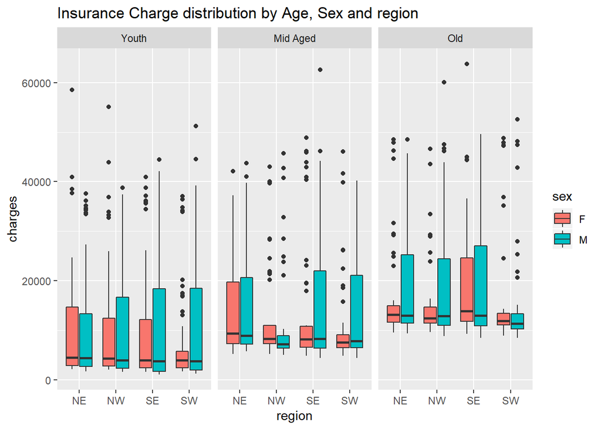

```r
#Visualise distribution of charges by agegroup,sex and region
df2.target%>%
   ggplot(aes(region,charges,fill=sex))+geom_boxplot()+facet_grid(~Agegroup)+
   ggtitle("Insurance Charge distribution by Age, Sex and region")
```

## Dataset3

The movieLens dataset is most often used for the purpose of recommender systems which aim to predict user movie ratings based on other users’ ratings. It needs to do a lot data clean before the do analysis .

```r
library(tidyverse)
```

#load data

```r
movies <- read_csv("movies.csv")
tail(movies)
```

```
## # A tibble: 6 x 3
##   movieId title                                     genres
##     <int> <chr>                                     <chr>
## 1  162542 Rustom (2016)                             Romance|Thriller
## 2  162672 Mohenjo Daro (2016)                       Adventure|Drama|Roman~
## 3  163056 Shin Godzilla (2016)                      Action|Adventure|Fant~
## 4  163949 The Beatles: Eight Days a Week - The Tou~ Documentary
## 5  164977 The Gay Desperado (1936)                  Comedy
## 6  164979 Women of '69, Unboxed                     Documentary
```